Saltar al contenido principal

# Análisis de un experimento agronómico con inti

Índice de cosecha en 15 genotipos de papa bajo riego y sequía

Autor/a

Bryan Chávez Velaisosa

Fecha de publicación

6 de noviembre de 2026

# 1 Introducción

El paquete `inti` (Lozano-Isla) reúne herramientas para analizar experimentos agrícolas: ANOVA, comparación de medias, gráficos listos para publicar y cálculo de heredabilidad. Su módulo de análisis se llama **Yupana** (“contar” en quechua).

En este trabajo se analiza la base `potato`, incluida en `inti`. Proviene de un experimento con **15 genotipos de papa** bajo **dos condiciones hídricas** (irrigado y sequía), en **5 bloques**.

**Pregunta:** ¿la sequía reduce el índice de cosecha (IC) y todos los genotipos responden igual?

# 2 Paquetes y datos

**Código**

```r
# Instalar una sola vez (ver README):
# install.packages(c("remotes", "tidyverse"))
# remotes::install_github("flavjack/inti")

library(inti)
library(tidyverse)

fb <- potato
glimpse(fb[, c("treat", "geno", "bloque", "hi", "tubdw", "biomdw")])
```

```
Rows: 150
Columns: 6
$ treat  <chr> "sequia", "sequia", "irrigado", "sequia", "irrigado", "irrigado…
$ geno   <chr> "G01", "G02", "G01", "G02", "G03", "G04", "G01", "G05", "G06", …
$ bloque <chr> "II", "IV", "III", "I", "II", "V", "I", "IV", "II", "I", "II", …
$ hi     <dbl> 0.45, 0.43, 0.45, 0.44, 0.64, 0.61, 0.41, 0.57, 0.05, 0.51, 0.4…
$ tubdw  <dbl> 19.80, 17.67, 38.02, 13.51, 51.15, 62.54, 22.45, 51.44, 2.37, 2…
$ biomdw <dbl> 51.78, 37.82, 83.59, 30.93, 80.16, 102.60, 55.06, 89.52, 47.49,…
```

Variables usadas:

- `treat`: condición hídrica (irrigado, sequia).
- `geno`: genotipo (G01 a G15).
- `bloque`: bloque (I a V).
- `hi`: índice de cosecha = peso seco de tubérculos / biomasa total.

## 2.1 Estructura del experimento

**Código**

```r
fb |> count(treat, bloque) |> pivot_wider(names_from = bloque, values_from = n)
```

```
# A tibble: 2 × 6
  treat        I    II   III    IV     V
  <chr>    <int> <int> <int> <int> <int>
1 irrigado    15    15    15    15    15
2 sequia      15    15    15    15    15
```

Es un **DBCA con arreglo factorial 15 × 2** (150 unidades experimentales).

$$Y_{ijk} = \mu + \rho_k + \alpha_i + \beta_j + (\alpha\beta)_{ij} + \varepsilon_{ijk}$$

# 3 Exploración de los datos

**Código**

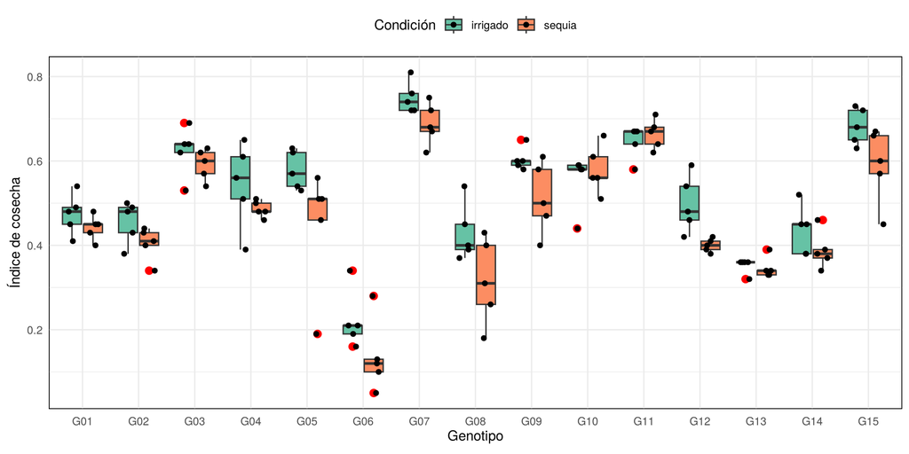

Figura 1: Distribución del índice de cosecha por genotipo y condición hídrica

```r
plot_raw(data = fb, type = "boxplot", x = "geno", y = "hi", group = "treat",
         ylab = "Índice de cosecha", xlab = "Genotipo", glab = "Condición")
```

# 4 Análisis de varianza

## 4.1 Primer modelo y revisión de supuestos

Antes de interpretar el ANOVA hay que comprobar que los residuos sean normales y que las varianzas sean homogéneas.

**Código**

```r
m0 <- aov(hi ~ bloque + geno * treat, data = fb)

shapiro.test(residuals(m0))                                  # normalidad
```

```
    Shapiro-Wilk normality test

data:  residuals(m0)
W = 0.95049, p-value = 3.6e-05
```

**Código**

```r
car::leveneTest(hi ~ interaction(geno, treat), data = fb)   # homogeneidad
```

```
Levene's Test for Homogeneity of Variance (center = median)
       Df F value Pr(>F)
group  29   0.904 0.6104
      120
```

**Código**

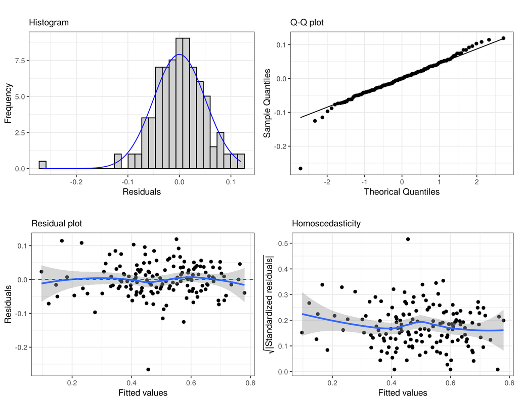

Figura 2: Diagnóstico de residuos del modelo inicial

```r
plot_diagnostic(data = fb, formula = hi ~ bloque + geno * treat) |>
  cowplot::plot_grid(plotlist = _, ncol = 2)
```

La prueba de Shapiro-Wilk da *p* < 0.05, así que **los residuos no son normales**. Los gráficos muestran que la causa es un punto muy alejado del resto. Se buscan observaciones con residuo estandarizado mayor a 3 en valor absoluto:

**Código**

```r
fb <- fb |> mutate(res_std = rstandard(m0))

fb |> filter(abs(res_std) > 3) |> select(geno, treat, bloque, hi, res_std)
```

```
  geno  treat bloque   hi   res_std
1  G05 sequia     IV 0.19 -5.293664
```

Hay **una sola observación atípica** (G05 en sequía, bloque IV, con un IC muy bajo). Puede ser un error de registro o una planta dañada. Se excluye y se vuelve a ajustar el modelo.

## 4.2 Modelo final con `yupana_analysis()`

**Código**

```r
fb_limpio <- fb |> filter(abs(res_std) <= 3) |> select(-res_std)

nrow(fb_limpio)   # 149 observaciones
```

```
[1] 149
```

**Código**

```r
rsl <- yupana_analysis(
  data          = fb_limpio,
  response      = "hi",
  model_factors = "bloque + geno * treat",
  comparison    = c("geno", "treat"),
  test_comp     = "SNK",
  sig_level     = 0.05
)

anova(rsl$anova)
```

```
Analysis of Variance Table

Response: hi
            Df  Sum Sq  Mean Sq F value    Pr(>F)
bloque       4 0.09659 0.024148  9.6727 8.861e-07 ***
geno        14 2.71440 0.193886 77.6619 < 2.2e-16 ***
treat        1 0.10375 0.103754 41.5592 2.786e-09 ***
geno:treat  14 0.06040 0.004315  1.7283   0.05908 .
Residuals  115 0.28710 0.002497
---
Signif. codes:  0 '***' 0.001 '**' 0.01 '*' 0.05 '.' 0.1 ' ' 1
```

**Código**

```r
shapiro.test(residuals(rsl$anova))
```

```
    Shapiro-Wilk normality test

data:  residuals(rsl$anova)
W = 0.99439, p-value = 0.836
```

**Código**

```r
car::leveneTest(hi ~ interaction(geno, treat), data = fb_limpio)
```

```
Levene's Test for Homogeneity of Variance (center = median)
       Df F value Pr(>F)
group  29  0.9939 0.4845
      119
```

Ahora ambas pruebas dan *p* > 0.05: **se cumplen los supuestos** y el ANOVA es válido.

**Código**

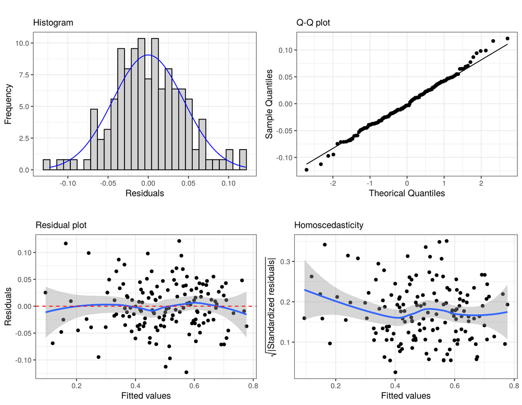

Figura 3: Diagnóstico de residuos del modelo final

```r
plot_diagnostic(data = fb_limpio, formula = hi ~ bloque + geno * treat) |>
  cowplot::plot_grid(plotlist = _, ncol = 2)
```

**Lectura del ANOVA (α = 0.05):**

- **Bloque**: significativo. Bloquear fue útil porque había variación entre bloques.
- **Genotipo**: altamente significativo; el IC depende mucho del genotipo.
- **Condición hídrica**: significativo; la sequía cambia el IC.
- **Genotipo × condición**: **no significativo** (*p* ≈ 0.06). No hay evidencia de que los genotipos respondan distinto a la sequía, así que se interpretan los **efectos principales** por separado.

# 5 Comparación de medias

## 5.1 Efecto de la sequía (Tukey)

**Código**

```r
mc_treat <- mean_comparison(
  data          = fb_limpio,
  response      = "hi",
  model_factors = "bloque + geno * treat",
  comparison    = "treat",
  test_comp     = "TUKEY"
)

mc_treat$comparison |> select(treat, hi, ste, sig)
```

```
     treat        hi        ste sig
1 irrigado 0.5234667 0.01630839   a
2   sequia 0.4697297 0.01762770   b
```

## 5.2 Efecto del genotipo (SNK)

**Código**

```r
mc_geno <- mean_comparison(
  data          = fb_limpio,
  response      = "hi",
  model_factors = "bloque + geno * treat",
  comparison    = "geno",
  test_comp     = "SNK"
)

mc_geno$comparison |> select(geno, hi, ste, sig) |> arrange(desc(hi))
```

```
   geno        hi         ste sig
1   G07 0.7190000 0.016696640   a
2   G11 0.6550000 0.011474610   b
3   G15 0.6360000 0.025828494   b
4   G03 0.6080000 0.015549205  bc
5   G10 0.5680000 0.018666667  cd
6   G09 0.5580000 0.024212026  cd
7   G05 0.5477778 0.018087578   d
8   G04 0.5150000 0.023722938   d
9   G01 0.4580000 0.013063945   e
10  G12 0.4490000 0.021880991   e
11  G02 0.4300000 0.015986105   e
12  G14 0.4120000 0.017435596  ef
13  G08 0.3730000 0.032112649  fg
14  G13 0.3490000 0.006574361   g
15  G06 0.1790000 0.027343494   h
```

**Código**

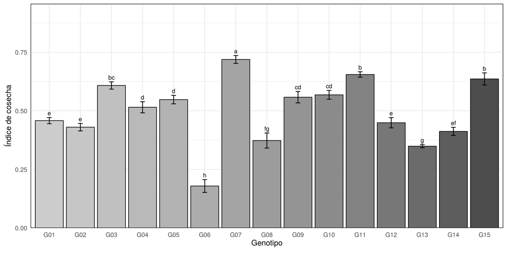

Figura 4: Índice de cosecha por genotipo (media ± error estándar). Letras distintas indican diferencias significativas (SNK, α = 0.05)

```r
mc_geno$comparison |>
  plot_smr(type   = "bar",
           x      = "geno",
           y      = "hi",
           xlab   = "Genotipo",
           ylab   = "Índice de cosecha",
           error  = "ste",
           sig    = "sig",
           legend = "none",
           color  = FALSE)
```

## 5.3 Genotipo en cada condición

Aunque la interacción no fue significativa, conviene ver el patrón:

**Código**

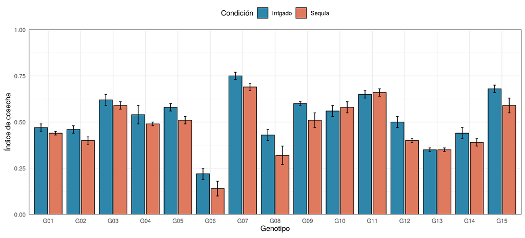

Figura 5: Índice de cosecha por genotipo en riego y sequía (media ± error estándar)

```r
rsl$meancomp |>
  plot_smr(type   = "bar",
           x      = "geno",
           y      = "hi",
           group  = "treat",
           xlab   = "Genotipo",
           ylab   = "Índice de cosecha",
           glab   = "Condición",
           error  = "ste",
           gtext  = c("Irrigado", "Sequía"),
           color  = c("#2E86AB", "#E07A5F"))
```

Casi todos los genotipos bajan su IC en sequía, en magnitudes parecidas. Esto concuerda con la interacción no significativa.

# 6 Heredabilidad con `H2cal()`

La heredabilidad (H²) indica qué proporción de la variación del IC se debe a los genotipos y no al ambiente. Se calcula con modelos mixtos, por separado para cada condición.

**Código**

```r
h2 <- fb_limpio |>
  split(~ treat) |>
  map(\(d) H2cal(data = d,
                 trait = "hi",
                 gen.name = "geno",
                 rep.n = 5,
                 fixed.model  = ~ 0 + (1|bloque) + geno,
                 random.model = ~ 1 + (1|bloque) + (1|geno),
                 emmeans = TRUE,
                 plot_diag = FALSE))

map_dfr(h2, \(x) x$tabsmr, .id = "condicion") |>
  select(condicion, mean, V.g, V.e, H2.s, H2.p, H2.c) |>
  mutate(across(where(is.numeric), \(x) round(x, 3)))
```

```
# A tibble: 2 × 7
  condicion  mean   V.g   V.e  H2.s  H2.p  H2.c
  <chr>     <dbl> <dbl> <dbl> <dbl> <dbl> <dbl>
1 irrigado  0.523 0.018 0.002 0.974 0.974 0.966
2 sequia    0.471 0.021 0.002 0.977 0.977 0.97
```

- `V.g`: varianza genotípica; `V.e`: varianza del error.
- `H2.s`, `H2.p`, `H2.c`: heredabilidad estándar, de Piepho y de Cullis.

Valores de H² cercanos a 1 indican que el IC está muy controlado por el genotipo, lo que favorece la selección.

# 7 Conclusiones

1. Se detectó y excluyó una observación atípica (G05, sequía, bloque IV). Con ella el modelo no cumplía normalidad; sin ella cumple ambos supuestos.
2. El índice de cosecha varía mucho entre genotipos; es el factor con mayor efecto.
3. La sequía reduce el índice de cosecha promedio respecto al riego.
4. No hay interacción significativa: la sequía afecta a los genotipos de forma similar, así que los mejores genotipos en riego también lo son en sequía.
5. La alta heredabilidad del IC indica que es un buen criterio de selección.

# 8 Referencias

Lozano-Isla, F. (2024). *inti: Tools and Statistical Procedures in Plant Science*. R package. https://inkaverse.com